# Genre Combinations and AI-Coded Review Dimensions: Random-Intercept Logistic Models (nAGQ = 1, Laplace)

## 1. Load data and align reviewer_id / book_id

```r
setwd("C:/Users/gujia/Downloads/annotation_run/nAGQ1")

library(lme4)
library(ggplot2)
library(dplyr)

df  <- read.csv("../annotated_50000sample.csv", check.names = FALSE,
                stringsAsFactors = FALSE, encoding = "UTF-8")
map <- read.csv("../book_id_mapping.csv", stringsAsFactors = FALSE,
                colClasses = c(book_id = "character", review_id = "character"))

df$row         <- seq_len(nrow(df)) - 1      # 0-based row index used by the Python script
df             <- merge(df, map, by = "row", all.x = TRUE, sort = TRUE)
df$reviewer_id <- df[["Reviewer ID"]]

table(df$match_type, useNA = "ifany")
```

```
          ambiguous          exact_text   exact_text+rating     fuzzy_text>=0.9
                154               45959                  20                 574
genre_disambiguated           prefix200           unmatched
                  1                3269                  23
```

```r
# keep reviews that were aligned to a book_id
df <- df[!is.na(df$book_id) & df$book_id != "", ]

c(reviews   = nrow(df),
  reviewers = length(unique(df$reviewer_id)),
  books     = length(unique(df$book_id)))
```

```
  reviews reviewers     books
    49823     12278     16159
```

```r
# how clustered is the data?
summary(as.vector(table(df$reviewer_id)))   # reviews per reviewer
```

```
   Min. 1st Qu.  Median    Mean 3rd Qu.    Max.
  1.000   1.000   2.000   4.058   5.000  78.000
```

```r
summary(as.vector(table(df$book_id)))       # reviews per book
```

```
   Min. 1st Qu.  Median    Mean 3rd Qu.    Max.
  1.000   1.000   2.000   3.083   3.000  89.000
```

## 2. Split Genre into combinations

Each `;`-separated piece of the Genre cell is one combination, e.g. `"fantasy, paranormal; fiction"` → `"fantasy, paranormal"` and `"fiction"`.

```r
genre_list <- lapply(strsplit(df$Genre, ";"), trimws)
genre_list <- lapply(genre_list, function(x) x[x != ""])
combos <- sort(unique(unlist(genre_list)))

# syntactic variable names: "fantasy, paranormal" -> "fantasy_paranormal"
clean_name <- function(x) gsub("_+", "_", gsub("[^A-Za-z0-9]+", "_", x))
data.frame(combination = combos, variable = clean_name(combos))
```

```
                              combination                             variable
1                                children                             children
2                         comics, graphic                       comics_graphic
3                     fantasy, paranormal                   fantasy_paranormal
4                                 fiction                              fiction
5  history, historical fiction, biography history_historical_fiction_biography
6                mystery, thriller, crime               mystery_thriller_crime
7                             non-fiction                          non_fiction
8                                  poetry                               poetry
9                                 romance                              romance
10                            young-adult                          young_adult
```

## 3. One-hot encoding

1 = the book has this combination, 0 = it does not.

```r
for (cmb in combos) {
  df[[clean_name(cmb)]] <- as.integer(vapply(genre_list, function(g) cmb %in% g, logical(1)))
}

# rename outcome columns: "Absence of Naive Realism_AI" -> "Absence_of_Naive_Realism_AI"
ai_cols <- grep("_AI$", names(df), value = TRUE)
names(df)[match(ai_cols, names(df))] <- clean_name(ai_cols)

df$reviewer_id <- factor(df$reviewer_id)
df$book_id     <- factor(df$book_id)

# number of reviews per combination
colSums(df[clean_name(combos)])
```

```
                            children                       comics_graphic
                                3975                                 2564
                  fantasy_paranormal                              fiction
                               29647                                48613
history_historical_fiction_biography               mystery_thriller_crime
                               11484                                23629
                         non_fiction                               poetry
                                1741                                  515
                             romance                          young_adult
                               37705                                31303
```

## 4. Random-intercept logistic models

$$\operatorname{logit} P(Y_{ijk}=1) = \beta_0 + \sum_{g}\beta_g\,\text{Genre}_{g,k} + u_{j} + v_{k},
\qquad u_j \sim N(0,\sigma^2_{\text{reviewer}}),\; v_k \sim N(0,\sigma^2_{\text{book}})$$

for review *i* written by reviewer *j* about book *k*. The two random intercepts absorb the non-independence of reviews written by the same reviewer and reviews of the same book.

```r
ctrl <- glmerControl(optimizer = "bobyqa", optCtrl = list(maxfun = 2e5))

# nAGQ = 1: Laplace approximation (robustness check of the nAGQ = 0 main results)
NAGQ <- 1
dir.create("models", showWarnings = FALSE)   # nAGQ1/models

# Fit a model, or load it if it was already fitted (fit_glmm_parallel.R fits all 7 in parallel).
# For nAGQ = 1 the nAGQ = 0 estimates are used as starting values.
fit_glmm <- function(name, formula, nAGQ = NAGQ) {
  path <- sprintf("models/%s_nagq%d.rds", name, nAGQ)
  if (file.exists(path)) return(readRDS(path))
  start <- NULL
  path0 <- sprintf("../models/%s_nagq0.rds", name)   # nAGQ = 0 fits = start values
  if (nAGQ > 0 && file.exists(path0)) {
    m0 <- readRDS(path0)
    start <- list(theta = getME(m0, "theta"), fixef = fixef(m0))
  }
  m <- glmer(formula, data = df, family = binomial, control = ctrl, nAGQ = nAGQ, start = start)
  saveRDS(m, path)
  m
}
```

### 4.1 Absence of Naive Realism

```r
g1 <- fit_glmm("g1",
               Absence_of_Naive_Realism_AI ~ 1 + children + comics_graphic + fantasy_paranormal +
                 fiction + history_historical_fiction_biography + mystery_thriller_crime +
                 non_fiction + poetry + romance + young_adult +
                 (1 | reviewer_id) + (1 | book_id))
summary(g1)
```

```
Generalized linear mixed model fit by maximum likelihood (Laplace
  Approximation) [glmerMod]
 Family: binomial  ( logit )
Formula: Absence_of_Naive_Realism_AI ~ 1 + children + comics_graphic +
    fantasy_paranormal + fiction + history_historical_fiction_biography +
    mystery_thriller_crime + non_fiction + poetry + romance +
    young_adult + (1 | reviewer_id) + (1 | book_id)
   Data: df
Control: ctrl

      AIC       BIC    logLik -2*log(L)  df.resid
  38541.4   38656.1  -19257.7   38515.4     49809

Scaled residuals:
    Min      1Q  Median      3Q     Max
-1.2304 -0.3616 -0.2922 -0.2420  4.6146

Random effects:
 Groups      Name        Variance Std.Dev.
 book_id     (Intercept) 0.3332   0.5773
 reviewer_id (Intercept) 0.8075   0.8986
Number of obs: 49822, groups:  book_id, 16159; reviewer_id, 12278

Fixed effects:
                                     Estimate Std. Error z value Pr(>|z|)
(Intercept)                          -2.26349    0.11988 -18.882  < 2e-16 ***
children                             -0.14861    0.06472  -2.296 0.021665 *
comics_graphic                       -0.47662    0.08202  -5.811 6.20e-09 ***
fantasy_paranormal                   -0.13357    0.03681  -3.628 0.000285 ***
fiction                               0.25345    0.11389   2.225 0.026053 *
history_historical_fiction_biography  0.14211    0.03985   3.566 0.000362 ***
mystery_thriller_crime               -0.04131    0.03436  -1.202 0.229291
non_fiction                           0.36070    0.09141   3.946 7.95e-05 ***
poetry                                0.29727    0.13850   2.146 0.031845 *
romance                              -0.35947    0.04243  -8.472  < 2e-16 ***
young_adult                           0.15927    0.03836   4.152 3.30e-05 ***
---
Signif. codes:  0 '***' 0.001 '**' 0.01 '*' 0.05 '.' 0.1 ' ' 1

Correlation of Fixed Effects:
            (Intr) chldrn cmcs_g fntsy_ fictin hst___ myst__ nn_fct poetry
children    -0.068
comcs_grphc -0.060  0.003
fntsy_prnrm -0.069 -0.042 -0.067
fiction     -0.909  0.006  0.008 -0.062
hstry_hst__ -0.057 -0.059 -0.003 -0.023 -0.050
mystry_thr_ -0.132  0.046  0.047 -0.189 -0.023  0.011
non_fiction -0.300  0.056 -0.238  0.156  0.215 -0.237  0.099
poetry       0.004 -0.009  0.031  0.057 -0.036 -0.004  0.041 -0.084
romance     -0.281  0.267  0.166  0.073  0.022  0.027  0.121  0.190  0.025
young_adult -0.040 -0.223 -0.041 -0.218 -0.074  0.118  0.067  0.011 -0.033
            romanc
children
comcs_grphc
fntsy_prnrm
fiction
hstry_hst__
mystry_thr_
non_fiction
poetry
romance
young_adult -0.230
```

### 4.2 Theme

```r
g2 <- fit_glmm("g2",
               Theme_AI ~ 1 + children + comics_graphic + fantasy_paranormal +
                 fiction + history_historical_fiction_biography + mystery_thriller_crime +
                 non_fiction + poetry + romance + young_adult +
                 (1 | reviewer_id) + (1 | book_id))
summary(g2)
```

```
Generalized linear mixed model fit by maximum likelihood (Laplace
  Approximation) [glmerMod]
 Family: binomial  ( logit )
Formula: Theme_AI ~ 1 + children + comics_graphic + fantasy_paranormal +
    fiction + history_historical_fiction_biography + mystery_thriller_crime +
    non_fiction + poetry + romance + young_adult + (1 | reviewer_id) +
    (1 | book_id)
   Data: df
Control: ctrl

      AIC       BIC    logLik -2*log(L)  df.resid
  64050.1   64164.7  -32012.1   64024.1     49810

Scaled residuals:
    Min      1Q  Median      3Q     Max
-3.7713 -0.8697  0.4945  0.6956  2.7178

Random effects:
 Groups      Name        Variance Std.Dev.
 book_id     (Intercept) 0.2232   0.4724
 reviewer_id (Intercept) 0.8155   0.9031
Number of obs: 49823, groups:  book_id, 16159; reviewer_id, 12278

Fixed effects:
                                     Estimate Std. Error z value Pr(>|z|)
(Intercept)                           0.49403    0.08037   6.147 7.89e-10 ***
children                             -0.18936    0.04627  -4.092 4.27e-05 ***
comics_graphic                       -0.33446    0.05669  -5.900 3.64e-09 ***
fantasy_paranormal                   -0.10310    0.02659  -3.877 0.000106 ***
fiction                               0.26215    0.07442   3.523 0.000427 ***
history_historical_fiction_biography  0.18120    0.02943   6.156 7.46e-10 ***
mystery_thriller_crime               -0.13626    0.02438  -5.588 2.30e-08 ***
non_fiction                           0.65426    0.07917   8.264  < 2e-16 ***
poetry                                0.32170    0.12108   2.657 0.007886 **
romance                              -0.45187    0.03214 -14.059  < 2e-16 ***
young_adult                           0.18763    0.02717   6.906 4.98e-12 ***
---
Signif. codes:  0 '***' 0.001 '**' 0.01 '*' 0.05 '.' 0.1 ' ' 1

Correlation of Fixed Effects:
            (Intr) chldrn cmcs_g fntsy_ fictin hst___ myst__ nn_fct poetry
children    -0.084
comcs_grphc -0.086  0.004
fntsy_prnrm -0.074 -0.043 -0.084
fiction     -0.882  0.007  0.012 -0.072
hstry_hst__ -0.052 -0.065  0.012 -0.024 -0.051
mystry_thr_ -0.153  0.050  0.050 -0.190 -0.017  0.011
non_fiction -0.255  0.054 -0.216  0.134  0.176 -0.215  0.088
poetry      -0.008 -0.009  0.021  0.049 -0.024 -0.006  0.040 -0.065
romance     -0.339  0.257  0.190  0.061  0.028  0.011  0.122  0.165  0.020
young_adult -0.049 -0.205 -0.030 -0.222 -0.067  0.107  0.069  0.011 -0.022
            romanc
children
comcs_grphc
fntsy_prnrm
fiction
hstry_hst__
mystry_thr_
non_fiction
poetry
romance
young_adult -0.201
```

### 4.3 Thought-Provoking

```r
g3 <- fit_glmm("g3",
               Thought_Provoking_AI ~ 1 + children + comics_graphic + fantasy_paranormal +
                 fiction + history_historical_fiction_biography + mystery_thriller_crime +
                 non_fiction + poetry + romance + young_adult +
                 (1 | reviewer_id) + (1 | book_id))
summary(g3)
```

```
Generalized linear mixed model fit by maximum likelihood (Laplace
  Approximation) [glmerMod]
 Family: binomial  ( logit )
Formula:
Thought_Provoking_AI ~ 1 + children + comics_graphic + fantasy_paranormal +
    fiction + history_historical_fiction_biography + mystery_thriller_crime +
    non_fiction + poetry + romance + young_adult + (1 | reviewer_id) +
    (1 | book_id)
   Data: df
Control: ctrl

      AIC       BIC    logLik -2*log(L)  df.resid
  51560.8   51675.4  -25767.4   51534.8     49810

Scaled residuals:
    Min      1Q  Median      3Q     Max
-2.3588 -0.4755 -0.3641 -0.2284  4.7108

Random effects:
 Groups      Name        Variance Std.Dev.
 book_id     (Intercept) 0.9209   0.9596
 reviewer_id (Intercept) 0.4156   0.6446
Number of obs: 49823, groups:  book_id, 16159; reviewer_id, 12278

Fixed effects:
                                     Estimate Std. Error z value Pr(>|z|)
(Intercept)                          -1.13540    0.10449 -10.866  < 2e-16 ***
children                             -0.36926    0.06227  -5.930 3.03e-09 ***
comics_graphic                       -0.48201    0.07494  -6.432 1.26e-10 ***
fantasy_paranormal                   -0.37357    0.03510 -10.644  < 2e-16 ***
fiction                               0.21581    0.09827   2.196   0.0281 *
history_historical_fiction_biography  0.09782    0.03878   2.522   0.0117 *
mystery_thriller_crime               -0.07024    0.03315  -2.119   0.0341 *
non_fiction                           1.00657    0.08753  11.499  < 2e-16 ***
poetry                                0.71964    0.13413   5.365 8.09e-08 ***
romance                              -0.79857    0.04031 -19.811  < 2e-16 ***
young_adult                           0.37183    0.03609  10.303  < 2e-16 ***
---
Signif. codes:  0 '***' 0.001 '**' 0.01 '*' 0.05 '.' 0.1 ' ' 1

```

[output cut: 8 more lines]

```
non_fiction -0.290  0.058 -0.223  0.153  0.202 -0.243  0.097
poetry      -0.003 -0.013  0.023  0.046 -0.032 -0.013  0.046 -0.071
romance     -0.324  0.265  0.184  0.095  0.034  0.040  0.133  0.191  0.026
young_adult -0.040 -0.227 -0.050 -0.226 -0.075  0.118  0.069  0.011 -0.027
            romanc
children
comcs_grphc
fntsy_prnrm
fiction
hstry_hst__
mystry_thr_
non_fiction
poetry
romance
young_adult -0.228
```

### 4.4 Ease

```r
g4 <- fit_glmm("g4",
               Ease_AI ~ 1 + children + comics_graphic + fantasy_paranormal +
                 fiction + history_historical_fiction_biography + mystery_thriller_crime +
                 non_fiction + poetry + romance + young_adult +
                 (1 | reviewer_id) + (1 | book_id))
summary(g4)
```

```
Generalized linear mixed model fit by maximum likelihood (Laplace
  Approximation) [glmerMod]
 Family: binomial  ( logit )
Formula: Ease_AI ~ 1 + children + comics_graphic + fantasy_paranormal +
    fiction + history_historical_fiction_biography + mystery_thriller_crime +
    non_fiction + poetry + romance + young_adult + (1 | reviewer_id) +
    (1 | book_id)
   Data: df
Control: ctrl

      AIC       BIC    logLik -2*log(L)  df.resid
  60498.0   60612.6  -30236.0   60472.0     49809

Scaled residuals:
    Min      1Q  Median      3Q     Max
-2.9728 -0.9990  0.4986  0.6135  2.1030

Random effects:
 Groups      Name        Variance Std.Dev.
 book_id     (Intercept) 0.3773   0.6143
 reviewer_id (Intercept) 0.4641   0.6813
Number of obs: 49822, groups:  book_id, 16159; reviewer_id, 12278

Fixed effects:
                                     Estimate Std. Error z value Pr(>|z|)
(Intercept)                           0.82449    0.08533   9.662  < 2e-16 ***
children                              0.43559    0.05082   8.572  < 2e-16 ***
comics_graphic                        0.35778    0.06055   5.909 3.44e-09 ***
fantasy_paranormal                   -0.08451    0.02813  -3.004  0.00266 **
fiction                              -0.08288    0.08000  -1.036  0.30024
history_historical_fiction_biography -0.09588    0.03077  -3.116  0.00183 **
mystery_thriller_crime                0.01775    0.02612   0.679  0.49683
non_fiction                          -0.11600    0.07527  -1.541  0.12327
poetry                               -0.07844    0.11793  -0.665  0.50595
romance                               0.24267    0.03295   7.364 1.78e-13 ***
young_adult                          -0.06918    0.02864  -2.416  0.01570 *
---
Signif. codes:  0 '***' 0.001 '**' 0.01 '*' 0.05 '.' 0.1 ' ' 1

Correlation of Fixed Effects:
            (Intr) chldrn cmcs_g fntsy_ fictin hst___ myst__ nn_fct poetry
children    -0.077
comcs_grphc -0.077  0.012
fntsy_prnrm -0.069 -0.040 -0.080
fiction     -0.891  0.008  0.010 -0.078
hstry_hst__ -0.055 -0.066  0.009 -0.020 -0.057
mystry_thr_ -0.150  0.049  0.047 -0.186 -0.019  0.014
non_fiction -0.274  0.057 -0.207  0.146  0.186 -0.228  0.095
poetry      -0.005 -0.007  0.026  0.048 -0.028 -0.010  0.041 -0.077
romance     -0.330  0.253  0.185  0.072  0.033  0.028  0.122  0.190  0.025
young_adult -0.037 -0.212 -0.038 -0.224 -0.074  0.108  0.068  0.007 -0.026
            romanc
children
comcs_grphc
fntsy_prnrm
fiction
hstry_hst__
mystry_thr_
non_fiction
poetry
romance
young_adult -0.211
```

### 4.5 Critic

```r
g5 <- fit_glmm("g5",
               Critic_AI ~ 1 + children + comics_graphic + fantasy_paranormal +
                 fiction + history_historical_fiction_biography + mystery_thriller_crime +
                 non_fiction + poetry + romance + young_adult +
                 (1 | reviewer_id) + (1 | book_id))
summary(g5)
```

```
Generalized linear mixed model fit by maximum likelihood (Laplace
  Approximation) [glmerMod]
 Family: binomial  ( logit )
Formula: Critic_AI ~ 1 + children + comics_graphic + fantasy_paranormal +
    fiction + history_historical_fiction_biography + mystery_thriller_crime +
    non_fiction + poetry + romance + young_adult + (1 | reviewer_id) +
    (1 | book_id)
   Data: df
Control: ctrl

      AIC       BIC    logLik -2*log(L)  df.resid
  64294.7   64409.3  -32134.3   64268.7     49810

Scaled residuals:
    Min      1Q  Median      3Q     Max
-3.1006 -0.8466  0.4808  0.7026  2.6525

Random effects:
 Groups      Name        Variance Std.Dev.
 book_id     (Intercept) 0.1211   0.348
 reviewer_id (Intercept) 1.0259   1.013
Number of obs: 49823, groups:  book_id, 16159; reviewer_id, 12278

Fixed effects:
                                     Estimate Std. Error z value Pr(>|z|)
(Intercept)                           0.19097    0.07748   2.465 0.013717 *
children                             -0.51665    0.04406 -11.727  < 2e-16 ***
comics_graphic                       -0.32996    0.05373  -6.140 8.23e-10 ***
fantasy_paranormal                    0.09084    0.02564   3.543 0.000396 ***
fiction                               0.06329    0.07174   0.882 0.377687
history_historical_fiction_biography  0.10449    0.02827   3.697 0.000219 ***
mystery_thriller_crime                0.19192    0.02342   8.195 2.51e-16 ***
non_fiction                          -0.38202    0.06835  -5.589 2.28e-08 ***
poetry                               -0.36289    0.10826  -3.352 0.000802 ***
romance                              -0.06507    0.03068  -2.121 0.033912 *
young_adult                           0.10688    0.02639   4.049 5.14e-05 ***
---
Signif. codes:  0 '***' 0.001 '**' 0.01 '*' 0.05 '.' 0.1 ' ' 1

Correlation of Fixed Effects:
            (Intr) chldrn cmcs_g fntsy_ fictin hst___ myst__ nn_fct poetry
children    -0.080
comcs_grphc -0.081  0.006
fntsy_prnrm -0.080 -0.046 -0.078
fiction     -0.882  0.007  0.012 -0.067
hstry_hst__ -0.060 -0.062  0.007 -0.014 -0.048
mystry_thr_ -0.149  0.042  0.048 -0.185 -0.015  0.016
non_fiction -0.277  0.062 -0.218  0.147  0.189 -0.232  0.095
poetry      -0.007 -0.006  0.029  0.052 -0.027 -0.003  0.039 -0.077
romance     -0.323  0.259  0.180  0.057  0.022  0.016  0.114  0.183  0.020
young_adult -0.055 -0.208 -0.030 -0.213 -0.070  0.108  0.073  0.013 -0.024
            romanc
children
comcs_grphc
fntsy_prnrm
fiction
hstry_hst__
mystry_thr_
non_fiction
poetry
romance
young_adult -0.201
```

### 4.6 Surprise

```r
g6 <- fit_glmm("g6",
               Surprise_AI ~ 1 + children + comics_graphic + fantasy_paranormal +
                 fiction + history_historical_fiction_biography + mystery_thriller_crime +
                 non_fiction + poetry + romance + young_adult +
                 (1 | reviewer_id) + (1 | book_id))
summary(g6)
```

```
Generalized linear mixed model fit by maximum likelihood (Laplace
  Approximation) [glmerMod]
 Family: binomial  ( logit )
Formula: Surprise_AI ~ 1 + children + comics_graphic + fantasy_paranormal +
    fiction + history_historical_fiction_biography + mystery_thriller_crime +
    non_fiction + poetry + romance + young_adult + (1 | reviewer_id) +
    (1 | book_id)
   Data: df
Control: ctrl

      AIC       BIC    logLik -2*log(L)  df.resid
  61167.3   61281.9  -30570.7   61141.3     49809

Scaled residuals:
    Min      1Q  Median      3Q     Max
-1.3963 -0.6447 -0.5582  1.1583  2.4821

Random effects:
 Groups      Name        Variance Std.Dev.
 book_id     (Intercept) 0.1355   0.3680
 reviewer_id (Intercept) 0.2764   0.5258
Number of obs: 49822, groups:  book_id, 16159; reviewer_id, 12278

Fixed effects:
                                       Estimate Std. Error z value Pr(>|z|)
(Intercept)                          -1.0548390  0.0776199 -13.590  < 2e-16 ***
children                             -0.3502845  0.0459233  -7.628 2.39e-14 ***
comics_graphic                       -0.2449416  0.0556345  -4.403 1.07e-05 ***
fantasy_paranormal                    0.0646913  0.0250786   2.580  0.00989 **
fiction                              -0.0089053  0.0728402  -0.122  0.90270
history_historical_fiction_biography -0.0326214  0.0278594  -1.171  0.24163
mystery_thriller_crime                0.1849065  0.0232111   7.966 1.64e-15 ***
non_fiction                          -0.0009398  0.0712742  -0.013  0.98948
poetry                               -0.2266762  0.1139298  -1.990  0.04663 *
romance                               0.0236554  0.0298992   0.791  0.42884
young_adult                           0.1567131  0.0256482   6.110 9.96e-10 ***
---
Signif. codes:  0 '***' 0.001 '**' 0.01 '*' 0.05 '.' 0.1 ' ' 1

Correlation of Fixed Effects:
            (Intr) chldrn cmcs_g fntsy_ fictin hst___ myst__ nn_fct poetry
children    -0.079
comcs_grphc -0.079  0.004
fntsy_prnrm -0.061 -0.042 -0.079
fiction     -0.893  0.009  0.011 -0.078
hstry_hst__ -0.049 -0.061  0.009 -0.030 -0.056
mystry_thr_ -0.150  0.041  0.048 -0.195 -0.018  0.011
non_fiction -0.266  0.055 -0.210  0.140  0.180 -0.228  0.092
poetry      -0.004 -0.006  0.024  0.052 -0.026 -0.007  0.037 -0.074
romance     -0.334  0.254  0.186  0.066  0.035  0.029  0.121  0.185  0.022
young_adult -0.035 -0.200 -0.032 -0.233 -0.080  0.105  0.074  0.007 -0.030
            romanc
children
comcs_grphc
fntsy_prnrm
fiction
hstry_hst__
mystry_thr_
non_fiction
poetry
romance
young_adult -0.211
```

### 4.7 Change

```r
g7 <- fit_glmm("g7",
               Change_AI ~ 1 + children + comics_graphic + fantasy_paranormal +
                 fiction + history_historical_fiction_biography + mystery_thriller_crime +
                 non_fiction + poetry + romance + young_adult +
                 (1 | reviewer_id) + (1 | book_id))
summary(g7)
```

```
Generalized linear mixed model fit by maximum likelihood (Laplace
  Approximation) [glmerMod]
 Family: binomial  ( logit )
Formula: Change_AI ~ 1 + children + comics_graphic + fantasy_paranormal +
    fiction + history_historical_fiction_biography + mystery_thriller_crime +
    non_fiction + poetry + romance + young_adult + (1 | reviewer_id) +
    (1 | book_id)
   Data: df
Control: ctrl

      AIC       BIC    logLik -2*log(L)  df.resid
  10116.3   10230.9   -5045.2   10090.3     49810

Scaled residuals:
   Min     1Q Median     3Q    Max
-2.249  0.000  0.000  0.000 11.522

Random effects:
 Groups      Name        Variance Std.Dev.
 book_id     (Intercept) 731.0    27.04
 reviewer_id (Intercept) 723.9    26.91
Number of obs: 49823, groups:  book_id, 16159; reviewer_id, 12278

Fixed effects:
                                     Estimate Std. Error z value Pr(>|z|)
(Intercept)                          -30.8535     4.5332  -6.806    1e-11 ***
children                               2.7315     3.2340   0.845   0.3983
comics_graphic                        -4.9144     3.8006  -1.293   0.1960
fantasy_paranormal                    -2.8948     1.8340  -1.578   0.1145
fiction                               -4.7429     4.1576  -1.141   0.2540
history_historical_fiction_biography   0.6140     2.0645   0.297   0.7662
mystery_thriller_crime                 0.0434     1.7737   0.024   0.9805
non_fiction                            5.8712     3.3352   1.760   0.0783 .
poetry                                -4.6673     6.5410  -0.714   0.4755
romance                               -1.6873     2.0901  -0.807   0.4195
young_adult                            1.8293     2.0075   0.911   0.3622
---
Signif. codes:  0 '***' 0.001 '**' 0.01 '*' 0.05 '.' 0.1 ' ' 1

Correlation of Fixed Effects:
            (Intr) chldrn cmcs_g fntsy_ fictin hst___ myst__ nn_fct poetry
children    -0.089
comcs_grphc -0.012  0.012
fntsy_prnrm -0.116 -0.049 -0.043
fiction     -0.831  0.028 -0.026 -0.070
hstry_hst__ -0.140 -0.040 -0.042  0.059 -0.097
mystry_thr_ -0.125  0.032  0.011 -0.151 -0.065  0.071
non_fiction -0.414  0.035 -0.298  0.177  0.288 -0.255  0.097
poetry       0.023  0.023  0.073  0.056 -0.057  0.009  0.036 -0.092
romance     -0.323  0.280  0.128  0.123  0.014  0.086  0.058  0.236  0.047
young_adult -0.085 -0.258 -0.071 -0.118 -0.132  0.235  0.087  0.034 -0.097
            romanc
children
comcs_grphc
fntsy_prnrm
fiction
hstry_hst__
mystry_thr_
non_fiction
poetry
romance
young_adult -0.260
```

## 5. Tables

Fixed effects are reported on the log-odds scale and as odds ratios (OR) with Wald 95% CIs. OR > 1: reviews of books with this genre combination are more likely to be coded 1.

```r
make_table <- function(model, outcome) {
  ct <- as.data.frame(coef(summary(model)))
  names(ct) <- c("log_odds", "std_error", "z_value", "p_value")
  ct$term     <- rownames(ct)
  ct$OR       <- exp(ct$log_odds)
  ct$OR_lower <- exp(ct$log_odds - 1.96 * ct$std_error)
  ct$OR_upper <- exp(ct$log_odds + 1.96 * ct$std_error)
  ct$sig <- as.character(cut(ct$p_value, breaks = c(-Inf, .001, .01, .05, Inf),
                             labels = c("***", "**", "*", "")))
  ct$outcome <- outcome
  ct$n <- nobs(model)
  rownames(ct) <- NULL
  ct[, c("outcome", "term", "log_odds", "std_error", "z_value", "p_value", "sig",
         "OR", "OR_lower", "OR_upper", "n")]
}

make_re_table <- function(model, outcome) {
  vc <- as.data.frame(VarCorr(model))
  v_rev  <- vc$vcov[vc$grp == "reviewer_id"]
  v_book <- vc$vcov[vc$grp == "book_id"]
  total  <- v_rev + v_book + pi^2 / 3          # latent-scale residual variance of logit
  data.frame(outcome = outcome,
             var_reviewer = v_rev, var_book = v_book,
             ICC_reviewer = v_rev / total, ICC_book = v_book / total)
}
```

```r
res_g1 <- make_table(g1, "Absence_of_Naive_Realism")
knitr::kable(res_g1, digits = 4)
```

| outcome | term | log_odds | std_error | z_value | p_value | sig | OR | OR_lower | OR_upper | n |
| --- | --- | --- | --- | --- | --- | --- | --- | --- | --- | --- |
| Absence_of_Naive_Realism | (Intercept) | -2.2635 | 0.1199 | -18.8818 | 0.0000 | *** | 0.1040 | 0.0822 | 0.1315 | 49822 |
| Absence_of_Naive_Realism | children | -0.1486 | 0.0647 | -2.2962 | 0.0217 | * | 0.8619 | 0.7592 | 0.9785 | 49822 |
| Absence_of_Naive_Realism | comics_graphic | -0.4766 | 0.0820 | -5.8114 | 0.0000 | *** | 0.6209 | 0.5287 | 0.7292 | 49822 |
| Absence_of_Naive_Realism | fantasy_paranormal | -0.1336 | 0.0368 | -3.6283 | 0.0003 | *** | 0.8750 | 0.8141 | 0.9404 | 49822 |
| Absence_of_Naive_Realism | fiction | 0.2534 | 0.1139 | 2.2254 | 0.0261 | * | 1.2885 | 1.0307 | 1.6107 | 49822 |
| Absence_of_Naive_Realism | history_historical_fiction_biography | 0.1421 | 0.0398 | 3.5665 | 0.0004 | *** | 1.1527 | 1.0661 | 1.2463 | 49822 |
| Absence_of_Naive_Realism | mystery_thriller_crime | -0.0413 | 0.0344 | -1.2022 | 0.2293 |  | 0.9595 | 0.8970 | 1.0264 | 49822 |
| Absence_of_Naive_Realism | non_fiction | 0.3607 | 0.0914 | 3.9460 | 0.0001 | *** | 1.4343 | 1.1991 | 1.7158 | 49822 |
| Absence_of_Naive_Realism | poetry | 0.2973 | 0.1385 | 2.1463 | 0.0318 | * | 1.3462 | 1.0261 | 1.7660 | 49822 |
| Absence_of_Naive_Realism | romance | -0.3595 | 0.0424 | -8.4723 | 0.0000 | *** | 0.6980 | 0.6423 | 0.7586 | 49822 |
| Absence_of_Naive_Realism | young_adult | 0.1593 | 0.0384 | 4.1519 | 0.0000 | *** | 1.1727 | 1.0877 | 1.2642 | 49822 |

```r
res_g2 <- make_table(g2, "Theme")
knitr::kable(res_g2, digits = 4)
```

| outcome | term | log_odds | std_error | z_value | p_value | sig | OR | OR_lower | OR_upper | n |
| --- | --- | --- | --- | --- | --- | --- | --- | --- | --- | --- |
| Theme | (Intercept) | 0.4940 | 0.0804 | 6.1472 | 0.0000 | *** | 1.6389 | 1.4000 | 1.9185 | 49823 |
| Theme | children | -0.1894 | 0.0463 | -4.0922 | 0.0000 | *** | 0.8275 | 0.7557 | 0.9060 | 49823 |
| Theme | comics_graphic | -0.3345 | 0.0567 | -5.8997 | 0.0000 | *** | 0.7157 | 0.6405 | 0.7998 | 49823 |
| Theme | fantasy_paranormal | -0.1031 | 0.0266 | -3.8769 | 0.0001 | *** | 0.9020 | 0.8562 | 0.9503 | 49823 |
| Theme | fiction | 0.2622 | 0.0744 | 3.5227 | 0.0004 | *** | 1.2997 | 1.1233 | 1.5038 | 49823 |
| Theme | history_historical_fiction_biography | 0.1812 | 0.0294 | 6.1561 | 0.0000 | *** | 1.1987 | 1.1315 | 1.2698 | 49823 |
| Theme | mystery_thriller_crime | -0.1363 | 0.0244 | -5.5881 | 0.0000 | *** | 0.8726 | 0.8319 | 0.9153 | 49823 |
| Theme | non_fiction | 0.6543 | 0.0792 | 8.2641 | 0.0000 | *** | 1.9237 | 1.6472 | 2.2466 | 49823 |
| Theme | poetry | 0.3217 | 0.1211 | 2.6569 | 0.0079 | ** | 1.3795 | 1.0880 | 1.7489 | 49823 |
| Theme | romance | -0.4519 | 0.0321 | -14.0594 | 0.0000 | *** | 0.6364 | 0.5976 | 0.6778 | 49823 |
| Theme | young_adult | 0.1876 | 0.0272 | 6.9060 | 0.0000 | *** | 1.2064 | 1.1438 | 1.2724 | 49823 |

```r
res_g3 <- make_table(g3, "Thought_Provoking")
knitr::kable(res_g3, digits = 4)
```

| outcome | term | log_odds | std_error | z_value | p_value | sig | OR | OR_lower | OR_upper | n |
| --- | --- | --- | --- | --- | --- | --- | --- | --- | --- | --- |
| Thought_Provoking | (Intercept) | -1.1354 | 0.1045 | -10.8663 | 0.0000 | *** | 0.3213 | 0.2618 | 0.3943 | 49823 |
| Thought_Provoking | children | -0.3693 | 0.0623 | -5.9298 | 0.0000 | *** | 0.6912 | 0.6118 | 0.7810 | 49823 |
| Thought_Provoking | comics_graphic | -0.4820 | 0.0749 | -6.4320 | 0.0000 | *** | 0.6175 | 0.5332 | 0.7152 | 49823 |
| Thought_Provoking | fantasy_paranormal | -0.3736 | 0.0351 | -10.6444 | 0.0000 | *** | 0.6883 | 0.6425 | 0.7373 | 49823 |
| Thought_Provoking | fiction | 0.2158 | 0.0983 | 2.1962 | 0.0281 | * | 1.2409 | 1.0235 | 1.5044 | 49823 |
| Thought_Provoking | history_historical_fiction_biography | 0.0978 | 0.0388 | 2.5223 | 0.0117 | * | 1.1028 | 1.0220 | 1.1899 | 49823 |
| Thought_Provoking | mystery_thriller_crime | -0.0702 | 0.0332 | -2.1188 | 0.0341 | * | 0.9322 | 0.8735 | 0.9947 | 49823 |
| Thought_Provoking | non_fiction | 1.0066 | 0.0875 | 11.4994 | 0.0000 | *** | 2.7362 | 2.3048 | 3.2483 | 49823 |
| Thought_Provoking | poetry | 0.7196 | 0.1341 | 5.3651 | 0.0000 | *** | 2.0537 | 1.5789 | 2.6712 | 49823 |
| Thought_Provoking | romance | -0.7986 | 0.0403 | -19.8106 | 0.0000 | *** | 0.4500 | 0.4158 | 0.4870 | 49823 |
| Thought_Provoking | young_adult | 0.3718 | 0.0361 | 10.3030 | 0.0000 | *** | 1.4504 | 1.3513 | 1.5567 | 49823 |

```r
res_g4 <- make_table(g4, "Ease")
knitr::kable(res_g4, digits = 4)
```

| outcome | term | log_odds | std_error | z_value | p_value | sig | OR | OR_lower | OR_upper | n |
| --- | --- | --- | --- | --- | --- | --- | --- | --- | --- | --- |
| Ease | (Intercept) | 0.8245 | 0.0853 | 9.6623 | 0.0000 | *** | 2.2807 | 1.9295 | 2.6959 | 49822 |
| Ease | children | 0.4356 | 0.0508 | 8.5719 | 0.0000 | *** | 1.5459 | 1.3993 | 1.7078 | 49822 |
| Ease | comics_graphic | 0.3578 | 0.0605 | 5.9092 | 0.0000 | *** | 1.4302 | 1.2701 | 1.6104 | 49822 |
| Ease | fantasy_paranormal | -0.0845 | 0.0281 | -3.0041 | 0.0027 | ** | 0.9190 | 0.8697 | 0.9711 | 49822 |
| Ease | fiction | -0.0829 | 0.0800 | -1.0359 | 0.3002 |  | 0.9205 | 0.7869 | 1.0767 | 49822 |
| Ease | history_historical_fiction_biography | -0.0959 | 0.0308 | -3.1162 | 0.0018 | ** | 0.9086 | 0.8554 | 0.9650 | 49822 |
| Ease | mystery_thriller_crime | 0.0177 | 0.0261 | 0.6795 | 0.4968 |  | 1.0179 | 0.9671 | 1.0714 | 49822 |
| Ease | non_fiction | -0.1160 | 0.0753 | -1.5412 | 0.1233 |  | 0.8905 | 0.7683 | 1.0320 | 49822 |
| Ease | poetry | -0.0784 | 0.1179 | -0.6652 | 0.5059 |  | 0.9246 | 0.7338 | 1.1650 | 49822 |
| Ease | romance | 0.2427 | 0.0330 | 7.3641 | 0.0000 | *** | 1.2746 | 1.1949 | 1.3597 | 49822 |
| Ease | young_adult | -0.0692 | 0.0286 | -2.4159 | 0.0157 | * | 0.9332 | 0.8822 | 0.9870 | 49822 |

```r
res_g5 <- make_table(g5, "Critic")
knitr::kable(res_g5, digits = 4)
```

| outcome | term | log_odds | std_error | z_value | p_value | sig | OR | OR_lower | OR_upper | n |
| --- | --- | --- | --- | --- | --- | --- | --- | --- | --- | --- |
| Critic | (Intercept) | 0.1910 | 0.0775 | 2.4646 | 0.0137 | * | 1.2104 | 1.0399 | 1.4089 | 49823 |
| Critic | children | -0.5167 | 0.0441 | -11.7265 | 0.0000 | *** | 0.5965 | 0.5472 | 0.6503 | 49823 |
| Critic | comics_graphic | -0.3300 | 0.0537 | -6.1405 | 0.0000 | *** | 0.7190 | 0.6471 | 0.7988 | 49823 |
| Critic | fantasy_paranormal | 0.0908 | 0.0256 | 3.5428 | 0.0004 | *** | 1.0951 | 1.0414 | 1.1515 | 49823 |
| Critic | fiction | 0.0633 | 0.0717 | 0.8822 | 0.3777 |  | 1.0653 | 0.9256 | 1.2262 | 49823 |
| Critic | history_historical_fiction_biography | 0.1045 | 0.0283 | 3.6966 | 0.0002 | *** | 1.1101 | 1.0503 | 1.1734 | 49823 |
| Critic | mystery_thriller_crime | 0.1919 | 0.0234 | 8.1947 | 0.0000 | *** | 1.2116 | 1.1572 | 1.2685 | 49823 |
| Critic | non_fiction | -0.3820 | 0.0684 | -5.5890 | 0.0000 | *** | 0.6825 | 0.5969 | 0.7803 | 49823 |
| Critic | poetry | -0.3629 | 0.1083 | -3.3520 | 0.0008 | *** | 0.6957 | 0.5627 | 0.8601 | 49823 |
| Critic | romance | -0.0651 | 0.0307 | -2.1211 | 0.0339 | * | 0.9370 | 0.8823 | 0.9951 | 49823 |
| Critic | young_adult | 0.1069 | 0.0264 | 4.0492 | 0.0001 | *** | 1.1128 | 1.0567 | 1.1719 | 49823 |

```r
res_g6 <- make_table(g6, "Surprise")
knitr::kable(res_g6, digits = 4)
```

| outcome | term | log_odds | std_error | z_value | p_value | sig | OR | OR_lower | OR_upper | n |
| --- | --- | --- | --- | --- | --- | --- | --- | --- | --- | --- |
| Surprise | (Intercept) | -1.0548 | 0.0776 | -13.5898 | 0.0000 | *** | 0.3482 | 0.2991 | 0.4055 | 49822 |
| Surprise | children | -0.3503 | 0.0459 | -7.6276 | 0.0000 | *** | 0.7045 | 0.6438 | 0.7708 | 49822 |
| Surprise | comics_graphic | -0.2449 | 0.0556 | -4.4027 | 0.0000 | *** | 0.7828 | 0.7019 | 0.8729 | 49822 |
| Surprise | fantasy_paranormal | 0.0647 | 0.0251 | 2.5795 | 0.0099 | ** | 1.0668 | 1.0157 | 1.1206 | 49822 |
| Surprise | fiction | -0.0089 | 0.0728 | -0.1223 | 0.9027 |  | 0.9911 | 0.8593 | 1.1432 | 49822 |
| Surprise | history_historical_fiction_biography | -0.0326 | 0.0279 | -1.1709 | 0.2416 |  | 0.9679 | 0.9165 | 1.0222 | 49822 |
| Surprise | mystery_thriller_crime | 0.1849 | 0.0232 | 7.9663 | 0.0000 | *** | 1.2031 | 1.1496 | 1.2591 | 49822 |
| Surprise | non_fiction | -0.0009 | 0.0713 | -0.0132 | 0.9895 |  | 0.9991 | 0.8688 | 1.1488 | 49822 |
| Surprise | poetry | -0.2267 | 0.1139 | -1.9896 | 0.0466 | * | 0.7972 | 0.6376 | 0.9966 | 49822 |
| Surprise | romance | 0.0237 | 0.0299 | 0.7912 | 0.4288 |  | 1.0239 | 0.9657 | 1.0857 | 49822 |
| Surprise | young_adult | 0.1567 | 0.0256 | 6.1101 | 0.0000 | *** | 1.1697 | 1.1123 | 1.2300 | 49822 |

```r
res_g7 <- make_table(g7, "Change")
knitr::kable(res_g7, digits = 4)
```

| outcome | term | log_odds | std_error | z_value | p_value | sig | OR | OR_lower | OR_upper | n |
| --- | --- | --- | --- | --- | --- | --- | --- | --- | --- | --- |
| Change | (Intercept) | -30.8535 | 4.5332 | -6.8061 | 0.0000 | *** | 0.0000 | 0.0000 | 0.0000 | 49823 |
| Change | children | 2.7315 | 3.2340 | 0.8446 | 0.3983 |  | 15.3562 | 0.0271 | 8692.6917 | 49823 |
| Change | comics_graphic | -4.9144 | 3.8006 | -1.2930 | 0.1960 |  | 0.0073 | 0.0000 | 12.6142 | 49823 |
| Change | fantasy_paranormal | -2.8948 | 1.8340 | -1.5784 | 0.1145 |  | 0.0553 | 0.0015 | 2.0134 | 49823 |
| Change | fiction | -4.7429 | 4.1576 | -1.1408 | 0.2540 |  | 0.0087 | 0.0000 | 30.1456 | 49823 |
| Change | history_historical_fiction_biography | 0.6140 | 2.0645 | 0.2974 | 0.7662 |  | 1.8477 | 0.0323 | 105.6733 | 49823 |
| Change | mystery_thriller_crime | 0.0434 | 1.7737 | 0.0245 | 0.9805 |  | 1.0444 | 0.0323 | 33.7784 | 49823 |
| Change | non_fiction | 5.8712 | 3.3352 | 1.7604 | 0.0783 |  | 354.6881 | 0.5139 | 244822.5936 | 49823 |
| Change | poetry | -4.6673 | 6.5410 | -0.7135 | 0.4755 |  | 0.0094 | 0.0000 | 3474.0665 | 49823 |
| Change | romance | -1.6873 | 2.0901 | -0.8073 | 0.4195 |  | 0.1850 | 0.0031 | 11.1269 | 49823 |
| Change | young_adult | 1.8293 | 2.0075 | 0.9113 | 0.3622 |  | 6.2297 | 0.1218 | 318.6023 | 49823 |

### Random-effect variances and ICCs

```r
re_all <- rbind(make_re_table(g1, "Absence_of_Naive_Realism"),
                make_re_table(g2, "Theme"),
                make_re_table(g3, "Thought_Provoking"),
                make_re_table(g4, "Ease"),
                make_re_table(g5, "Critic"),
                make_re_table(g6, "Surprise"),
                make_re_table(g7, "Change"))
knitr::kable(re_all, digits = 3)
```

| outcome | var_reviewer | var_book | ICC_reviewer | ICC_book |
| --- | --- | --- | --- | --- |
| Absence_of_Naive_Realism | 0.808 | 0.333 | 0.182 | 0.075 |
| Theme | 0.816 | 0.223 | 0.188 | 0.052 |
| Thought_Provoking | 0.416 | 0.921 | 0.090 | 0.199 |
| Ease | 0.464 | 0.377 | 0.112 | 0.091 |
| Critic | 1.026 | 0.121 | 0.231 | 0.027 |
| Surprise | 0.276 | 0.135 | 0.075 | 0.037 |
| Change | 723.917 | 731.016 | 0.496 | 0.501 |

```r
res_all <- rbind(res_g1, res_g2, res_g3, res_g4, res_g5, res_g6, res_g7)
write.csv(res_all, "genre_glmer_coefficients_nagq1.csv", row.names = FALSE)
write.csv(re_all,  "genre_glmer_random_effects_nagq1.csv", row.names = FALSE)
```

## 6. Graphs

```r
genre_vars <- c("children", "comics_graphic", "fantasy_paranormal", "fiction",
                "history_historical_fiction_biography", "mystery_thriller_crime",
                "non_fiction", "poetry", "romance", "young_adult")

genre_labels <- c("Children", "Comics & Graphic", "Fantasy & Paranormal", "Fiction",
                  "History / Biography", "Mystery / Thriller / Crime", "Non-fiction",
                  "Poetry", "Romance", "Young Adult")

make_plot_data <- function(res) {
  res %>%
    filter(term %in% genre_vars) %>%
    mutate(significance = ifelse(sig == "", "ns", sig),
           term = factor(term, levels = genre_vars, labels = genre_labels))
}

plot_or <- function(res, title) {
  ggplot(make_plot_data(res), aes(x = OR, y = term)) +
    geom_vline(xintercept = 1, linetype = "dashed", color = "gray50") +
    geom_errorbar(aes(xmin = OR_lower, xmax = OR_upper), width = 0.2, orientation = "y") +
    geom_point(aes(color = significance), size = 3) +
    scale_x_log10() +
    scale_color_manual(values = c("***" = "#B2182B", "**" = "#EF8A62",
                                  "*" = "#67A9CF", "ns" = "gray65"),
                       drop = FALSE) +
    labs(title = title,
         subtitle = paste0("Random intercepts for reviewer and book (nAGQ = ", NAGQ, ")"),
         x = "Odds Ratio (log scale, 95% CI)", y = "Genre Combination",
         color = "Significance") +
    theme_minimal(base_size = 12) +
    theme(plot.title = element_text(face = "bold", hjust = 0.5),
          plot.subtitle = element_text(hjust = 0.5),
          legend.position = "bottom")
}
```

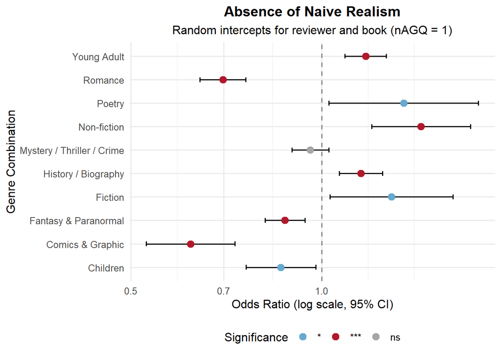

```r
q1 <- plot_or(res_g1, "Absence of Naive Realism")
q1
```

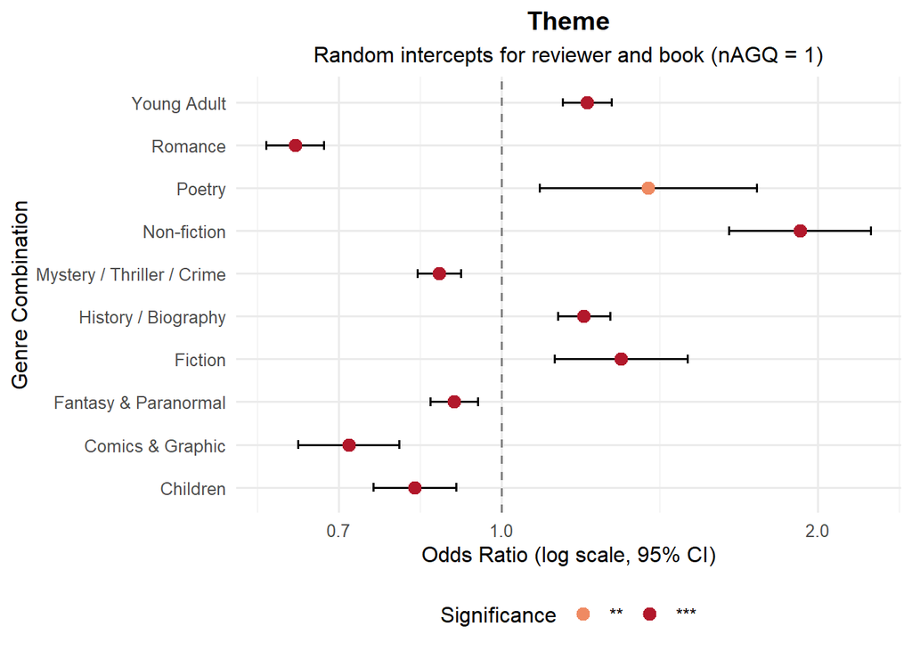

```r
q2 <- plot_or(res_g2, "Theme")
q2
```

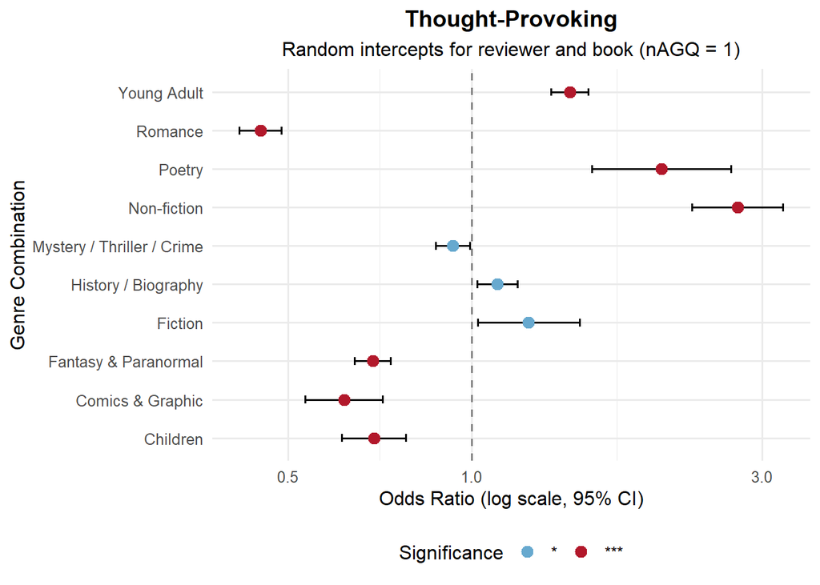

```r
q3 <- plot_or(res_g3, "Thought-Provoking")
q3
```

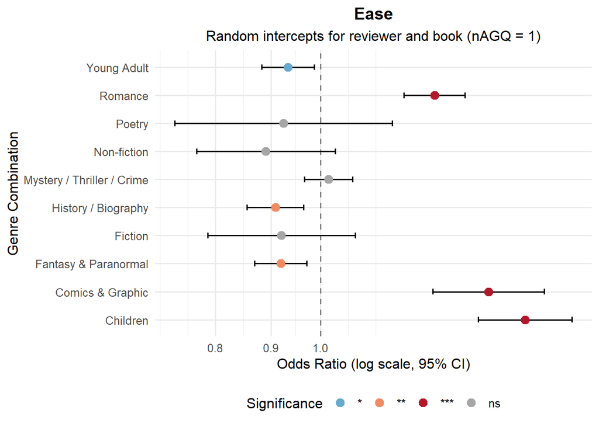

```r
q4 <- plot_or(res_g4, "Ease")
q4
```

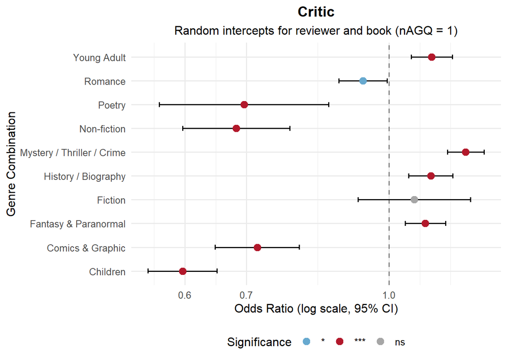

```r
q5 <- plot_or(res_g5, "Critic")
q5
```

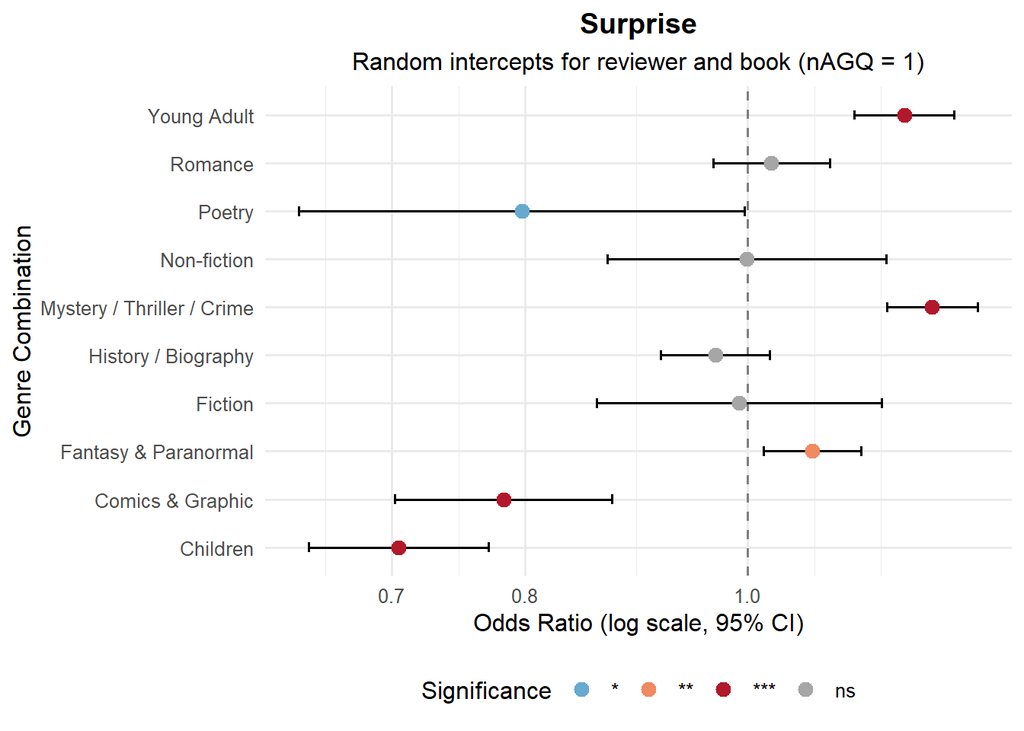

```r
q6 <- plot_or(res_g6, "Surprise")
q6
```

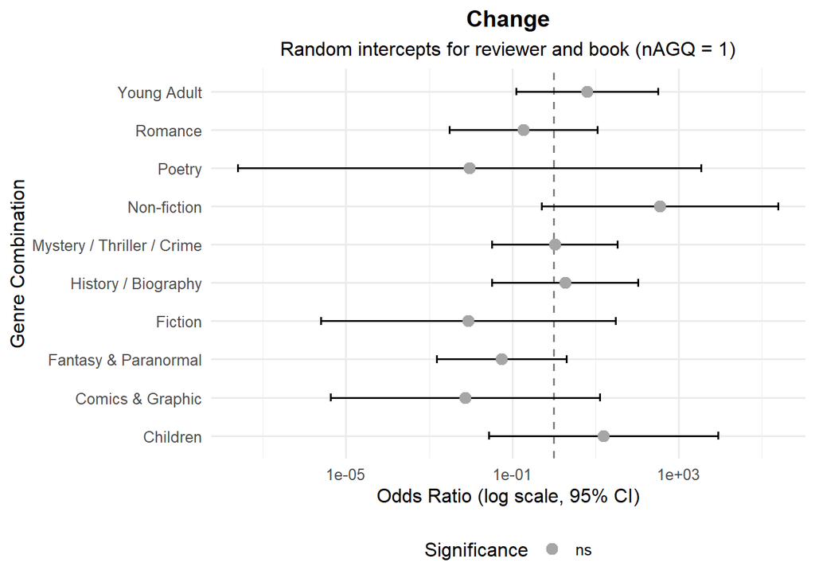

```r
q7 <- plot_or(res_g7, "Change")
q7
```

```r
ggsave("GLMM_nAGQ1_Graph_1_Naive_Realism.png",     q1, width = 9, height = 6, dpi = 300)
ggsave("GLMM_nAGQ1_Graph_2_Theme.png",             q2, width = 9, height = 6, dpi = 300)
ggsave("GLMM_nAGQ1_Graph_3_Thought_Provoking.png", q3, width = 9, height = 6, dpi = 300)
ggsave("GLMM_nAGQ1_Graph_4_Ease.png",              q4, width = 9, height = 6, dpi = 300)
ggsave("GLMM_nAGQ1_Graph_5_Critic.png",            q5, width = 9, height = 6, dpi = 300)
ggsave("GLMM_nAGQ1_Graph_6_Surprise.png",          q6, width = 9, height = 6, dpi = 300)
ggsave("GLMM_nAGQ1_Graph_7_Change.png",            q7, width = 9, height = 6, dpi = 300)
```

### Overview: all constructs

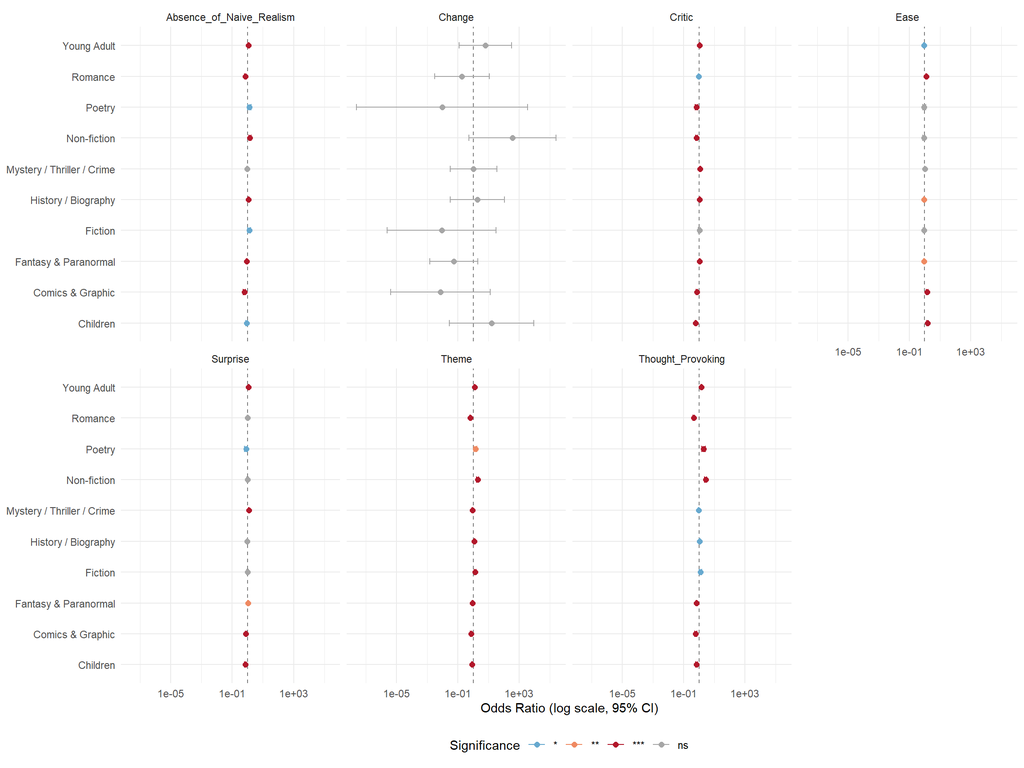

```r
ggplot(make_plot_data(res_all), aes(x = OR, y = term, color = significance)) +
  geom_vline(xintercept = 1, linetype = "dashed", color = "gray50") +
  geom_errorbar(aes(xmin = OR_lower, xmax = OR_upper), width = 0.2, orientation = "y") +
  geom_point(size = 2) +
  scale_x_log10() +
  facet_wrap(~ outcome, ncol = 4) +
  scale_color_manual(values = c("***" = "#B2182B", "**" = "#EF8A62",
                                "*" = "#67A9CF", "ns" = "gray65")) +
  labs(x = "Odds Ratio (log scale, 95% CI)", y = NULL, color = "Significance") +
  theme_minimal(base_size = 11) +
  theme(legend.position = "bottom")
```

## 7. Comparison with nAGQ = 0

```r
outcome_names <- c("Absence_of_Naive_Realism", "Theme", "Thought_Provoking", "Ease",
                   "Critic", "Surprise", "Change")
m0_list <- lapply(1:7, function(k) readRDS(sprintf("../models/g%d_nagq0.rds", k)))
res_all_0 <- do.call(rbind, Map(make_table, m0_list, outcome_names))
re_all_0  <- do.call(rbind, Map(make_re_table, m0_list, outcome_names))

cmp <- merge(res_all_0[, c("outcome", "term", "log_odds", "std_error", "p_value", "sig")],
             res_all[,   c("outcome", "term", "log_odds", "std_error", "p_value", "sig")],
             by = c("outcome", "term"), suffixes = c("_q0", "_q1"))
cmp <- cmp[cmp$term %in% genre_vars, ]
cmp$diff_log_odds  <- cmp$log_odds_q1 - cmp$log_odds_q0
cmp$same_sig_at_05 <- (cmp$p_value_q0 < .05) == (cmp$p_value_q1 < .05)
cmp$same_sign      <- sign(cmp$log_odds_q0) == sign(cmp$log_odds_q1)
cmp$outcome <- factor(cmp$outcome, levels = outcome_names)
cmp <- cmp[order(cmp$outcome, cmp$term), ]
write.csv(cmp, "nagq0_vs_nagq1_coefficients.csv", row.names = FALSE)
knitr::kable(cmp, digits = 4, row.names = FALSE)
```

| outcome | term | log_odds_q0 | std_error_q0 | p_value_q0 | sig_q0 | log_odds_q1 | std_error_q1 | p_value_q1 | sig_q1 | diff_log_odds | same_sig_at_05 | same_sign |
| --- | --- | --- | --- | --- | --- | --- | --- | --- | --- | --- | --- | --- |
| Absence_of_Naive_Realism | children | -0.1349 | 0.0586 | 0.0212 | * | -0.1486 | 0.0647 | 0.0217 | * | -0.0137 | TRUE | TRUE |
| Absence_of_Naive_Realism | comics_graphic | -0.4278 | 0.0741 | 0.0000 | *** | -0.4766 | 0.0820 | 0.0000 | *** | -0.0488 | TRUE | TRUE |
| Absence_of_Naive_Realism | fantasy_paranormal | -0.1214 | 0.0333 | 0.0003 | *** | -0.1336 | 0.0368 | 0.0003 | *** | -0.0122 | TRUE | TRUE |
| Absence_of_Naive_Realism | fiction | 0.2334 | 0.1034 | 0.0240 | * | 0.2534 | 0.1139 | 0.0261 | * | 0.0200 | TRUE | TRUE |
| Absence_of_Naive_Realism | history_historical_fiction_biography | 0.1278 | 0.0362 | 0.0004 | *** | 0.1421 | 0.0398 | 0.0004 | *** | 0.0143 | TRUE | TRUE |
| Absence_of_Naive_Realism | mystery_thriller_crime | -0.0349 | 0.0311 | 0.2621 |  | -0.0413 | 0.0344 | 0.2293 |  | -0.0064 | TRUE | TRUE |
| Absence_of_Naive_Realism | non_fiction | 0.3217 | 0.0834 | 0.0001 | *** | 0.3607 | 0.0914 | 0.0001 | *** | 0.0390 | TRUE | TRUE |
| Absence_of_Naive_Realism | poetry | 0.2696 | 0.1273 | 0.0341 | * | 0.2973 | 0.1385 | 0.0318 | * | 0.0276 | TRUE | TRUE |
| Absence_of_Naive_Realism | romance | -0.3331 | 0.0384 | 0.0000 | *** | -0.3595 | 0.0424 | 0.0000 | *** | -0.0264 | TRUE | TRUE |
| Absence_of_Naive_Realism | young_adult | 0.1427 | 0.0347 | 0.0000 | *** | 0.1593 | 0.0384 | 0.0000 | *** | 0.0166 | TRUE | TRUE |
| Theme | children | -0.1663 | 0.0460 | 0.0003 | *** | -0.1894 | 0.0463 | 0.0000 | *** | -0.0230 | TRUE | TRUE |
| Theme | comics_graphic | -0.2999 | 0.0563 | 0.0000 | *** | -0.3345 | 0.0567 | 0.0000 | *** | -0.0345 | TRUE | TRUE |
| Theme | fantasy_paranormal | -0.0944 | 0.0265 | 0.0004 | *** | -0.1031 | 0.0266 | 0.0001 | *** | -0.0087 | TRUE | TRUE |
| Theme | fiction | 0.2304 | 0.0740 | 0.0019 | ** | 0.2622 | 0.0744 | 0.0004 | *** | 0.0317 | TRUE | TRUE |
| Theme | history_historical_fiction_biography | 0.1561 | 0.0292 | 0.0000 | *** | 0.1812 | 0.0294 | 0.0000 | *** | 0.0251 | TRUE | TRUE |
| Theme | mystery_thriller_crime | -0.1215 | 0.0243 | 0.0000 | *** | -0.1363 | 0.0244 | 0.0000 | *** | -0.0148 | TRUE | TRUE |
| Theme | non_fiction | 0.5861 | 0.0776 | 0.0000 | *** | 0.6543 | 0.0792 | 0.0000 | *** | 0.0682 | TRUE | TRUE |
| Theme | poetry | 0.2776 | 0.1191 | 0.0198 | * | 0.3217 | 0.1211 | 0.0079 | ** | 0.0441 | TRUE | TRUE |
| Theme | romance | -0.3929 | 0.0319 | 0.0000 | *** | -0.4519 | 0.0321 | 0.0000 | *** | -0.0589 | TRUE | TRUE |
| Theme | young_adult | 0.1671 | 0.0270 | 0.0000 | *** | 0.1876 | 0.0272 | 0.0000 | *** | 0.0205 | TRUE | TRUE |
| Thought_Provoking | children | -0.3058 | 0.0586 | 0.0000 | *** | -0.3693 | 0.0623 | 0.0000 | *** | -0.0635 | TRUE | TRUE |
| Thought_Provoking | comics_graphic | -0.4024 | 0.0705 | 0.0000 | *** | -0.4820 | 0.0749 | 0.0000 | *** | -0.0797 | TRUE | TRUE |
| Thought_Provoking | fantasy_paranormal | -0.3250 | 0.0331 | 0.0000 | *** | -0.3736 | 0.0351 | 0.0000 | *** | -0.0486 | TRUE | TRUE |
| Thought_Provoking | fiction | 0.1705 | 0.0922 | 0.0644 |  | 0.2158 | 0.0983 | 0.0281 | * | 0.0453 | FALSE | TRUE |
| Thought_Provoking | history_historical_fiction_biography | 0.0835 | 0.0366 | 0.0225 | * | 0.0978 | 0.0388 | 0.0117 | * | 0.0143 | TRUE | TRUE |
| Thought_Provoking | mystery_thriller_crime | -0.0594 | 0.0312 | 0.0572 |  | -0.0702 | 0.0332 | 0.0341 | * | -0.0109 | FALSE | TRUE |
| Thought_Provoking | non_fiction | 0.8285 | 0.0837 | 0.0000 | *** | 1.0066 | 0.0875 | 0.0000 | *** | 0.1781 | TRUE | TRUE |
| Thought_Provoking | poetry | 0.6032 | 0.1287 | 0.0000 | *** | 0.7196 | 0.1341 | 0.0000 | *** | 0.1164 | TRUE | TRUE |
| Thought_Provoking | romance | -0.6806 | 0.0381 | 0.0000 | *** | -0.7986 | 0.0403 | 0.0000 | *** | -0.1180 | TRUE | TRUE |
| Thought_Provoking | young_adult | 0.3026 | 0.0339 | 0.0000 | *** | 0.3718 | 0.0361 | 0.0000 | *** | 0.0692 | TRUE | TRUE |
| Ease | children | 0.3876 | 0.0498 | 0.0000 | *** | 0.4356 | 0.0508 | 0.0000 | *** | 0.0480 | TRUE | TRUE |
| Ease | comics_graphic | 0.3186 | 0.0595 | 0.0000 | *** | 0.3578 | 0.0605 | 0.0000 | *** | 0.0392 | TRUE | TRUE |
| Ease | fantasy_paranormal | -0.0731 | 0.0277 | 0.0083 | ** | -0.0845 | 0.0281 | 0.0027 | ** | -0.0114 | TRUE | TRUE |
| Ease | fiction | -0.0676 | 0.0786 | 0.3897 |  | -0.0829 | 0.0800 | 0.3002 |  | -0.0153 | TRUE | TRUE |
| Ease | history_historical_fiction_biography | -0.0851 | 0.0303 | 0.0050 | ** | -0.0959 | 0.0308 | 0.0018 | ** | -0.0107 | TRUE | TRUE |
| Ease | mystery_thriller_crime | 0.0156 | 0.0257 | 0.5448 |  | 0.0177 | 0.0261 | 0.4968 |  | 0.0022 | TRUE | TRUE |
| Ease | non_fiction | -0.0999 | 0.0743 | 0.1788 |  | -0.1160 | 0.0753 | 0.1233 |  | -0.0161 | TRUE | TRUE |
| Ease | poetry | -0.0705 | 0.1164 | 0.5448 |  | -0.0784 | 0.1179 | 0.5059 |  | -0.0079 | TRUE | TRUE |
| Ease | romance | 0.2165 | 0.0325 | 0.0000 | *** | 0.2427 | 0.0330 | 0.0000 | *** | 0.0262 | TRUE | TRUE |
| Ease | young_adult | -0.0583 | 0.0282 | 0.0387 | * | -0.0692 | 0.0286 | 0.0157 | * | -0.0109 | TRUE | TRUE |
| Critic | children | -0.4582 | 0.0439 | 0.0000 | *** | -0.5167 | 0.0441 | 0.0000 | *** | -0.0584 | TRUE | TRUE |
| Critic | comics_graphic | -0.2967 | 0.0536 | 0.0000 | *** | -0.3300 | 0.0537 | 0.0000 | *** | -0.0332 | TRUE | TRUE |
| Critic | fantasy_paranormal | 0.0775 | 0.0256 | 0.0024 | ** | 0.0908 | 0.0256 | 0.0004 | *** | 0.0134 | TRUE | TRUE |
| Critic | fiction | 0.0538 | 0.0716 | 0.4526 |  | 0.0633 | 0.0717 | 0.3777 |  | 0.0095 | TRUE | TRUE |
| Critic | history_historical_fiction_biography | 0.0892 | 0.0282 | 0.0015 | ** | 0.1045 | 0.0283 | 0.0002 | *** | 0.0153 | TRUE | TRUE |
| Critic | mystery_thriller_crime | 0.1724 | 0.0233 | 0.0000 | *** | 0.1919 | 0.0234 | 0.0000 | *** | 0.0195 | TRUE | TRUE |
| Critic | non_fiction | -0.3346 | 0.0682 | 0.0000 | *** | -0.3820 | 0.0684 | 0.0000 | *** | -0.0474 | TRUE | TRUE |
| Critic | poetry | -0.3305 | 0.1079 | 0.0022 | ** | -0.3629 | 0.1083 | 0.0008 | *** | -0.0324 | TRUE | TRUE |
| Critic | romance | -0.0505 | 0.0306 | 0.0985 |  | -0.0651 | 0.0307 | 0.0339 | * | -0.0146 | FALSE | TRUE |
| Critic | young_adult | 0.0960 | 0.0263 | 0.0003 | *** | 0.1069 | 0.0264 | 0.0001 | *** | 0.0109 | TRUE | TRUE |
| Surprise | children | -0.3286 | 0.0452 | 0.0000 | *** | -0.3503 | 0.0459 | 0.0000 | *** | -0.0217 | TRUE | TRUE |
| Surprise | comics_graphic | -0.2299 | 0.0547 | 0.0000 | *** | -0.2449 | 0.0556 | 0.0000 | *** | -0.0151 | TRUE | TRUE |
| Surprise | fantasy_paranormal | 0.0606 | 0.0248 | 0.0143 | * | 0.0647 | 0.0251 | 0.0099 | ** | 0.0041 | TRUE | TRUE |
| Surprise | fiction | -0.0086 | 0.0719 | 0.9049 |  | -0.0089 | 0.0728 | 0.9027 |  | -0.0003 | TRUE | TRUE |
| Surprise | history_historical_fiction_biography | -0.0299 | 0.0275 | 0.2762 |  | -0.0326 | 0.0279 | 0.2416 |  | -0.0027 | TRUE | TRUE |
| Surprise | mystery_thriller_crime | 0.1734 | 0.0229 | 0.0000 | *** | 0.1849 | 0.0232 | 0.0000 | *** | 0.0115 | TRUE | TRUE |
| Surprise | non_fiction | -0.0010 | 0.0701 | 0.9887 |  | -0.0009 | 0.0713 | 0.9895 |  | 0.0001 | TRUE | TRUE |
| Surprise | poetry | -0.2115 | 0.1119 | 0.0589 |  | -0.2267 | 0.1139 | 0.0466 | * | -0.0152 | FALSE | TRUE |
| Surprise | romance | 0.0203 | 0.0295 | 0.4913 |  | 0.0237 | 0.0299 | 0.4288 |  | 0.0034 | TRUE | TRUE |
| Surprise | young_adult | 0.1455 | 0.0253 | 0.0000 | *** | 0.1567 | 0.0256 | 0.0000 | *** | 0.0112 | TRUE | TRUE |
| Change | children | -0.3278 | 0.1222 | 0.0073 | ** | 2.7315 | 3.2340 | 0.3983 |  | 3.0594 | FALSE | FALSE |
| Change | comics_graphic | -0.4941 | 0.1417 | 0.0005 | *** | -4.9144 | 3.8006 | 0.1960 |  | -4.4202 | FALSE | TRUE |
| Change | fantasy_paranormal | -0.5774 | 0.0669 | 0.0000 | *** | -2.8948 | 1.8340 | 0.1145 |  | -2.3174 | FALSE | TRUE |
| Change | fiction | 0.0857 | 0.1705 | 0.6155 |  | -4.7429 | 4.1576 | 0.2540 |  | -4.8285 | TRUE | FALSE |
| Change | history_historical_fiction_biography | 0.1242 | 0.0748 | 0.0966 |  | 0.6140 | 2.0645 | 0.7662 |  | 0.4898 | TRUE | TRUE |
| Change | mystery_thriller_crime | -0.3782 | 0.0660 | 0.0000 | *** | 0.0434 | 1.7737 | 0.9805 |  | 0.4216 | FALSE | FALSE |
| Change | non_fiction | 1.0641 | 0.1302 | 0.0000 | *** | 5.8712 | 3.3352 | 0.0783 |  | 4.8072 | FALSE | TRUE |
| Change | poetry | 0.0196 | 0.2353 | 0.9334 |  | -4.6673 | 6.5410 | 0.4755 |  | -4.6870 | TRUE | FALSE |
| Change | romance | -0.6705 | 0.0760 | 0.0000 | *** | -1.6873 | 2.0901 | 0.4195 |  | -1.0168 | FALSE | TRUE |
| Change | young_adult | 0.3804 | 0.0703 | 0.0000 | *** | 1.8293 | 2.0075 | 0.3622 |  | 1.4489 | FALSE | TRUE |

```r
re_cmp <- merge(re_all_0, re_all, by = "outcome", suffixes = c("_q0", "_q1"))
re_cmp <- re_cmp[match(outcome_names, re_cmp$outcome),
                 c("outcome", "var_reviewer_q0", "var_reviewer_q1", "var_book_q0", "var_book_q1",
                   "ICC_reviewer_q0", "ICC_reviewer_q1", "ICC_book_q0", "ICC_book_q1")]
write.csv(re_cmp, "nagq0_vs_nagq1_random_effects.csv", row.names = FALSE)
knitr::kable(re_cmp, digits = 3, row.names = FALSE)
```

| outcome | var_reviewer_q0 | var_reviewer_q1 | var_book_q0 | var_book_q1 | ICC_reviewer_q0 | ICC_reviewer_q1 | ICC_book_q0 | ICC_book_q1 |
| --- | --- | --- | --- | --- | --- | --- | --- | --- |
| Absence_of_Naive_Realism | 0.616 | 0.808 | 0.192 | 0.333 | 0.150 | 0.182 | 0.047 | 0.075 |
| Theme | 0.808 | 0.816 | 0.218 | 0.223 | 0.187 | 0.188 | 0.051 | 0.052 |
| Thought_Provoking | 0.362 | 0.416 | 0.777 | 0.921 | 0.082 | 0.090 | 0.176 | 0.199 |
| Ease | 0.450 | 0.464 | 0.359 | 0.377 | 0.110 | 0.112 | 0.088 | 0.091 |
| Critic | 1.021 | 1.026 | 0.119 | 0.121 | 0.230 | 0.231 | 0.027 | 0.027 |
| Surprise | 0.265 | 0.276 | 0.126 | 0.135 | 0.072 | 0.075 | 0.034 | 0.037 |
| Change | 0.293 | 723.917 | 0.875 | 731.016 | 0.066 | 0.496 | 0.196 | 0.501 |